# Trabajo Integrador - Módulos 3, 4 y 5

Diplomatura en Ciencias computacionales y humanidades digitales - UNSAM

Camila Cupo y Camila Cotorás

2023-10-17

## General

### Carga de paquetes a utilizar

```r
#install.packages('topicmodels')
#install.packages("reshape2")
#install.packages('quanteda')
#install.packages('stm')
#install.packages("knitr")
#install.packages('reshape')
#install.packages("tm")
#install.packages("wordcloud")
#install.packages("wordcloud2")
#install.packages('ggplot2')
#install.packages("ggwordcloud")



library(tidyverse)
library(tidytext)
library(forcats)
library(topicmodels)
library(reshape2)
library(quanteda)
library(stm)
library(knitr)
library(reshape)
library(tm)
library(wordcloud)
library(wordcloud2)
library(ggplot2)
library(ggwordcloud)
```

### Base de datos para el trabajo

```r
# corpus <- read_csv('./data/M5_corpus_medios.csv')  %>%
#   mutate(text=texto) %>%
#   mutate(id = row_number())


corpus <- read_csv('./data/M5_corpus_medios.csv')

corpus_tidy <- corpus %>%
  dplyr::rename(text = texto) %>%
  mutate(id = row_number()) %>%
  mutate(medio = as.factor(medio)) %>%
                mutate(medio = str_replace(medio, "clarin" , "Clarín")) %>%
                mutate(medio = str_replace(medio, "lanacion" , "La Nación")) %>%
                mutate(medio = str_replace(medio, "pagina12" , "Página 12")) %>%
                mutate(medio = str_replace(medio, "minutouno" , "Minuto Uno")) %>%
                mutate(medio = str_replace(medio, "cronica" , "Crónica")) %>%
                mutate(medio = str_replace(medio, "telam" , "Telam")) %>%
                mutate(medio = str_replace(medio, "perfil" , "Perfil")) %>%
                mutate(medio = str_replace(medio, "infobae" , "Infobae"))

length(unique(corpus$titulo))
```

```
## [1] 6967
```

### Limpieza y transformación de las bases para todos los ejercicios

Luego de realizar la tokenización del corpus, es decir, separar los textos de las noticias en palabras, eliminamos aquellas palabras comunes como conectores, artículos, verbos básicos, modismos, etc., llamadas stopwords, que no aportan a la hora del análisis. Convertimos el texto a minúscula y quitamos los caracteres especiales del español, para facilitar el trabajo.

```r
corpus_tidy_tokens <- corpus_tidy %>%
        mutate(text = stringi::stri_trans_general(text,"Latin-ASCII"),
                       titulo = stringi::stri_trans_general(titulo,"Latin-ASCII")) %>%
        mutate(text = str_replace_all(text, '[[:digit:]]+', '')) %>%
        unnest_tokens(word, text)

stop_words <- read_csv('https://raw.githubusercontent.com/Alir3z4/stop-words/master/spanish.txt', col_names=FALSE) %>%
        mutate(word = X1) %>%
        mutate(word = stringi::stri_trans_general(word, "Latin-ASCII")) %>%
        bind_rows(tibble(word=c('más', 'también', 'está', 'según', 'además', 'qué', 'año', 'años', 'fuente', 'compartir', 'guardar','embed', 'comentar', 'twitter', 'facebook', 'whatsapp', '2019', 'gusta', 'mail', 'así', 'él', 'leé', 'nacion', 'cronica.com.ar','jpg','loading', 'minutouno.com', 'páginai12', '01', 'cp', 'cronicavirales', 'eltrece', 'l.l', 'd.s', 'ámbito.com', 'ea', 'télam.la', 'infobae','f.f', 'afv', 'qt', 'f.d.s', 'a.ghd', 'fh', 'hd', 'lxs','fel', 'pct', 'jpe', 'a.g','afp','email', 'r.d', 'protected', 'tweet', 'jpa', 'b.d.n', 'exar','ap', 'www.pagina12', 'emj', 'clarín','ano', 'anos', 'the', 'clarin', 'ambito.com', 'www.pagina.com.ar', 'twitter.com', 'h.b', 'telam.la', 'nacional.el', 'caff', 'mb', 'mc', 'mbya', 'dgcim', 'paginai')))

corpus_tidy_tokens <- corpus_tidy_tokens %>%
  anti_join(stop_words)
```

## Palabras más utilizadas

### ¿Cuáles son las palabras más utilizadas en cada uno de los medios? ¿Pueden verse diferencias?

Para contestar esta pregunta armamos un data frame con la cantidad de repeticiones de cada palabra en cada uno de los medios y otro data frame con el total de palabras de cada medio, las mismas sirvieron de base para las métricas y visualizaciones

```r
conteo_por_medio <- corpus_tidy_tokens %>%
        group_by(medio, word) %>%
        summarise(n = n()) %>%
        arrange(desc(n)) %>%
        ungroup()
conteo_total <- conteo_por_medio %>%
  group_by(medio) %>%
  summarize(total = sum(n))

conteo_por_medio <- conteo_por_medio %>%
                left_join(conteo_total) %>%
                ungroup() %>%
                arrange(desc(n))
```

Para realizar el análisis de las palabras más utilizadas en cada uno de los medios, trabajamos a partir de la métrica term frequency, la misma refiere a la frecuencia con la que aparece una palabra en un documento, o en este caso, en un conjunto de noticias pertenecientes a cada medio en cuestión. Observamos aquí que unas pocas palabras son muy mencionadas y que la gran mayoría aparece muy poco.

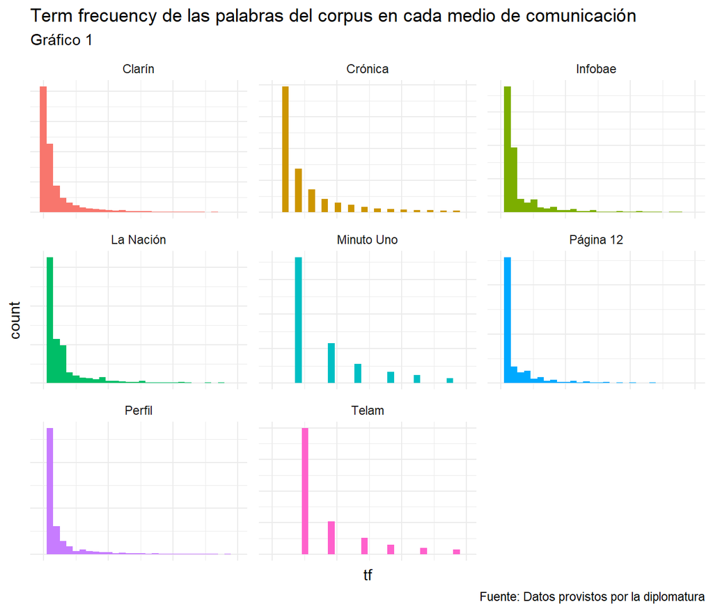

```r
conteo_por_medio %>%
        mutate(tf = n/total) %>%
        ggplot(aes(tf, fill = medio)) +
                geom_histogram(show.legend = FALSE) +
                xlim(NA, 0.00015) +
                facet_wrap(~medio,  scales = "free_y") +
                theme_minimal() +
                theme(axis.text.x = element_blank(), axis.text.y = element_blank())+
                labs(title="Term frecuency de las palabras del corpus en cada medio de comunicación",
                     subtitle="Gráfico 1",
                     caption="Fuente: Datos provistos por la diplomatura")
```

Para visualizar de manera clara y poder comparar cuáles fueron las palabras más mencionadas en cada medio de comunicación realizamos nubes de palabras que se plasman a continuación

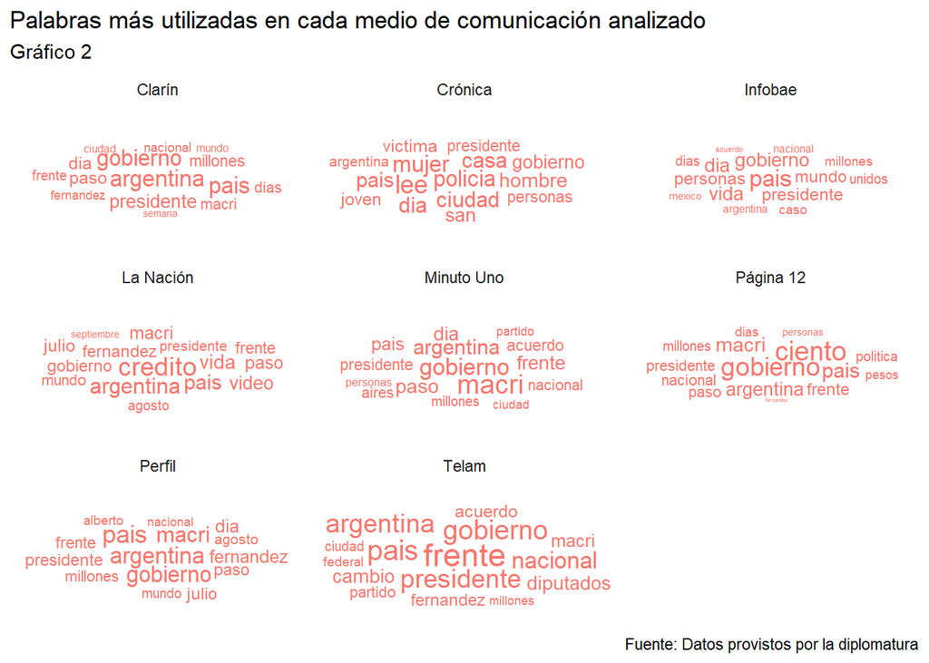

```r
conteo_por_medio_wordcloud <- conteo_por_medio %>%
  mutate(wordProp = n/total)

conteo_por_medio_wordcloud %>%
  group_by(medio) %>%
  slice_max(n, n = 15) %>%
  ungroup() %>%
  ggplot(aes(label = word, size = abs(wordProp),
             color = wordProp < 0, angle_group = wordProp < 0)) +
  geom_text_wordcloud_area() +
  theme_minimal() +
  facet_wrap(~medio) +
  labs(title="Palabras más utilizadas en cada medio de comunicación analizado",
       subtitle="Gráfico 2",
       caption="Fuente: Datos provistos por la diplomatura")
```

Utilizamos luego la informatividad de cada término a partir de la métrica Inverse Document Frequency (idf). Esta métrica disminuye el peso de las palabras de uso común y aumenta el peso de las que no se usan mucho en nuestro corpus de noticias, lo cual podría darnos algún tipo de caracterización más propia de cada medio, ya que como se observa en las nubes de palabras, encontramos bastantes similitudes entre las palabras mencionadas en cada uno de ellos.

La combinación de ambas métricas (tf-idf), se utiliza para encontrar las palabras importantes para el contenido de cada medio, disminuyendo el peso de las palabras de uso común y aumentando el peso de las palabras que no se usan mucho en el resto del corpus. Lo que se busca con esta métrica es encontrar las palabras importantes para cada medio de comunicación pero no aquellas que sean demasiado comunes, tal como sí ocurre si miramos solamente la métrica TF. Se calcula a partir de multiplicar ambas métricas: la frecuencia de cada término ajustada por la importancia que tiene en el corpus. Los resultados se presentan a continuación:

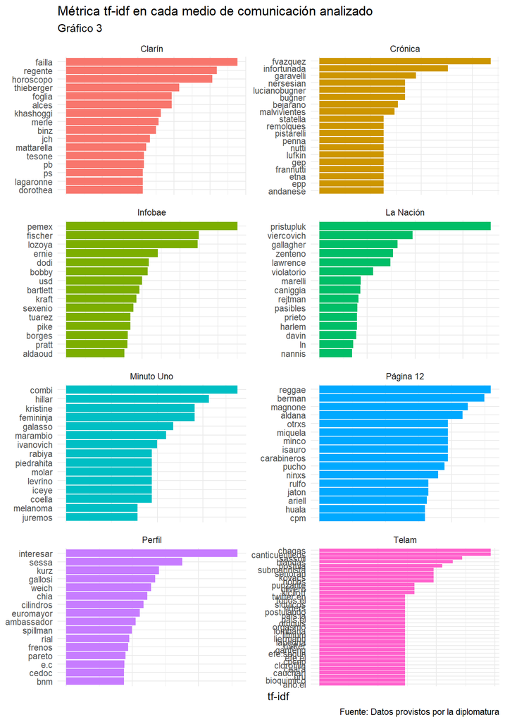

```r
medios_tf_idf <- conteo_por_medio %>%
  bind_tf_idf(word, medio, n)

medios_tf_idf %>%
  group_by(medio) %>%
        slice_max(tf_idf, n = 15) %>%
        ungroup() %>%
        ggplot(aes(tf_idf, fct_reorder(word, tf_idf), fill = medio)) +
        geom_col(show.legend = FALSE) +
        facet_wrap(~medio, ncol = 2, scales = "free") +
        labs(x = "tf-idf", y = NULL) +
        theme_minimal()  +
        theme(axis.text.x = element_blank())+
        labs(title="Métrica tf-idf en cada medio de comunicación analizado",
             subtitle="Gráfico 3",
       caption="Fuente: Datos provistos por la diplomatura")
```

El presente gráfico de barras muestra que el análisis mediante la métrica tdf-idf no nos proporcionó resultados interesantes o al menos interpretables. Se observa que las palabras propias de cada medio refieren en muchos casos a apellidos de periodistas o fotógrafos de cada uno de los medios, o algunas palabras sobre algún tema específico que haya sido recurrente en ese diario, pero que no brinda información demasiado clara para interpretar. Esto ocurrió incluso después de agregar más palabras a la lista de las stopwords como “cronica.com”, etc, que formaban parte del cuerpo de la noticia y por eso se encontraban en la columna de texto. Una inferencia que podemos hacer respecto a la cantidad de palabras “inexistentes” que aparecen con esta métrica, más allá de que quitemos a mano unas cuantas, es el incremento en los errores de tipeo y ortografía que se viene dando en los diarios online desde hace ya varios años, debido principalmente a que ya no emplean correctores y editores para sus escritos y noticias.

Entendemos a partir de estos resultados que para interpretar este corpus de noticias, es necesario aplicar otro tipo de técnica para realizar un análisis más certero.

## Modelado de tópicos

#### Es posible detectar tópicos o temas en un corpus de noticias a partir de técnicas de procesamiento de lenguaje natural para caracterizar la agenda mediática en un período determinado de tiempo. Trabajaremos a partir de dos métodos diferentes: LDA y STM, para poder comparar los resultados y observar en todo caso cuál brinda mejor información sobre el corpus.

### Principales tópicos del corpus

#### MODELO LDA

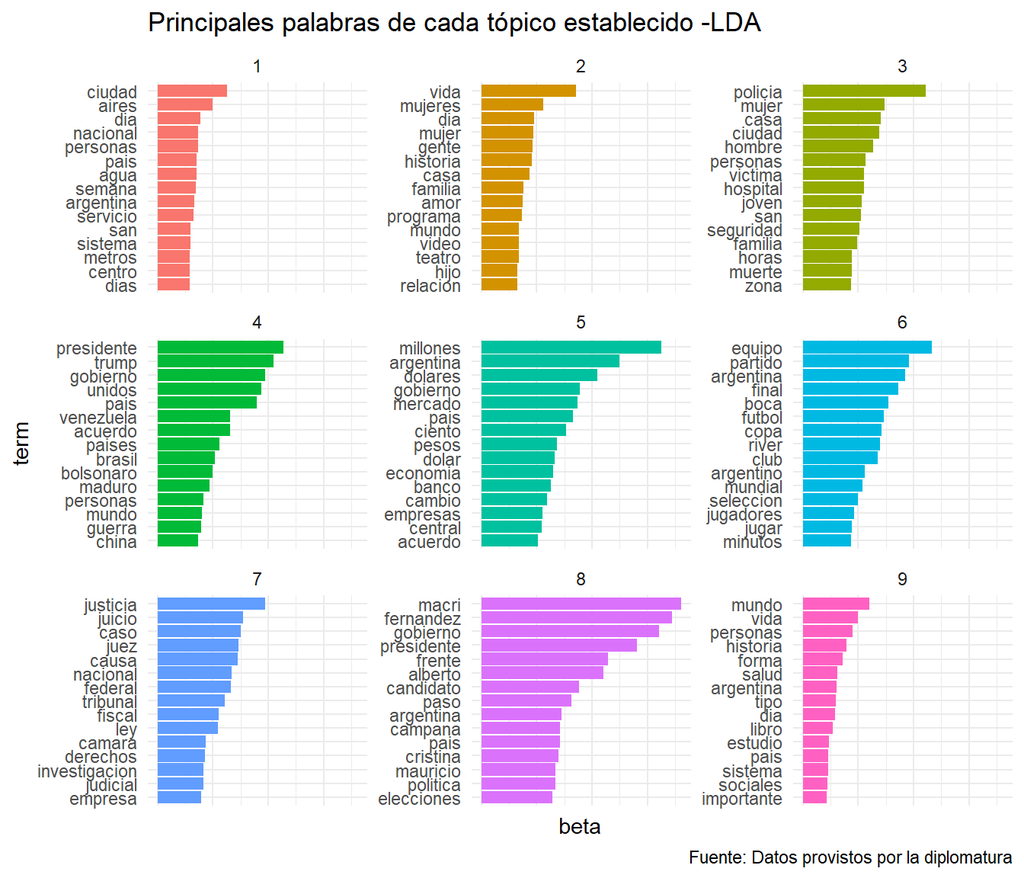

```r
# word_counts <- corpus_tidy_tokens %>%
#         group_by(id, word) %>%
#         summarise(n=n()) %>%
#         ungroup()
#
#  corpus_dtm <- word_counts %>%
#                   cast_dtm(id, word, n)
#
#  lda_9 <- LDA(corpus_dtm, k=9, control = list(seed = 1234))
#
#
# write_rds(lda_9, './models/lda_9.rds')
lda_9 <- read_rds('./models/lda_9.rds')

betas_lda_9 <- tidy(lda_9, matrix='beta')
doc_2_topics_lda_9 <- tidy(lda_9, matrix='gamma')

betas_lda_9 %>%
  group_by(topic) %>%
  slice_max(beta, n = 15) %>%
  ungroup() %>%
  arrange(topic, -beta) %>%
  mutate(term = reorder_within(term, beta, topic)) %>%
  ggplot(aes(beta, term, fill = factor(topic))) +
  geom_col(show.legend = FALSE) +
  facet_wrap(~ topic, scales='free_y') +
  scale_y_reordered() +
  theme_minimal() +
  theme(axis.text.x = element_blank())+
  labs(title="Principales palabras de cada tópico establecido -LDA",
       caption="Fuente: Datos provistos por la diplomatura")
```

Nombramos los tópicos:

TÓPICOS (LDA):

1. CIUDAD Y SERVICIOS
2. INTERESES PERSONALES
3. SEGURIDAD
4. POLÍTICA INTERNACIONAL
5. ECONOMÍA
6. DEPORTES
7. JUDICIALES
8. ELECCIONES NACIONALES
9. SOCIEDAD

#### MODELO STM

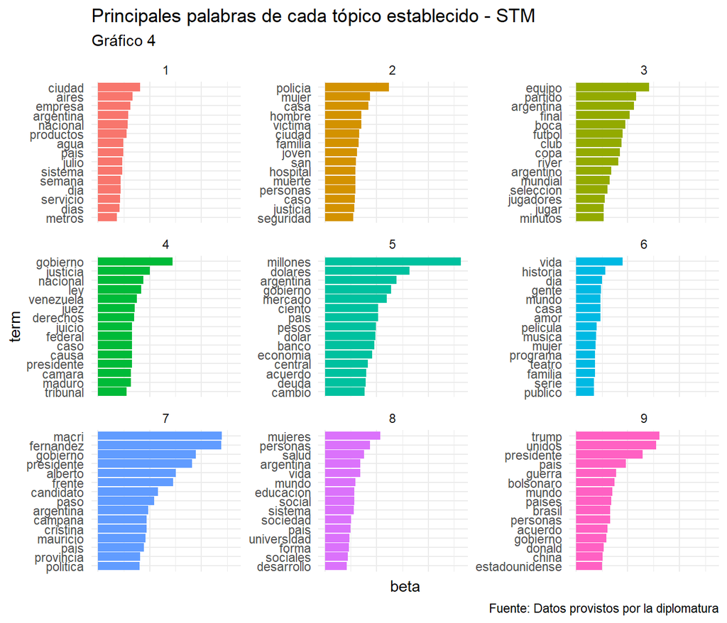

```r
betas_stm_9 %>%
  group_by(topic) %>%
  slice_max(beta, n = 15) %>%
  ungroup() %>%
  arrange(topic, -beta) %>%
  mutate(term = reorder_within(term, beta, topic)) %>%
  ggplot(aes(beta, term, fill = factor(topic))) +
  geom_col(show.legend = FALSE) +
  facet_wrap(~ topic, scales='free_y') +
  scale_y_reordered() +
  theme_minimal() +
  theme(axis.text.x = element_blank())+
  labs(title="Principales palabras de cada tópico establecido - STM",
       subtitle="Gráfico 4",
       caption="Fuente: Datos provistos por la diplomatura")
```

En el modelado a partir de STM se reemplazan las distribuciones de probabilidad que se usan en LDA por modelos lineales generalizados para poder correlacionar las covarabiales con la distribución de tópicos por medio y de palabras por tópico. Además nos permite observar algunas métricas específicas tales como

Highest prob, representando las palabras dentro de cada tema con la mayor probabilidad. Frex, combina la frecuencia con la exclusividad.

Vamos a utilizarlas:

```r
labelTopics(stm_9)
```

```
## Topic 1 Top Words:
##       Highest Prob: ciudad, aires, empresa, argentina, nacional, productos, agua
##       FREX: horoscopo, harina, android, girasol, nublado, virgo, facturacion
##       Lift: aabe, aadeja, abaratan, abarcando, abastecerlo, abastecerse, abboghlouyan
##       Score: soja, horoscopo, maiz, eclipse, nublado, productos, cultivos
## Topic 2 Top Words:
##       Highest Prob: policia, mujer, casa, hombre, victima, ciudad, familia
##       FREX: comisaria, autopsia, pericias, ufi, veppo, pepo, puccio
##       Lift: amputado, aubriana, bacci, bazza, beckwith, benetton, bisconti
##       Score: homicidio, policia, detenido, comisaria, prision, fiscal, hospital
## Topic 3 Top Words:
##       Highest Prob: equipo, partido, argentina, final, boca, futbol, club
##       FREX: torneo, messi, entrenador, campeon, libertadores, goles, plantel
##       Lift: abbatangelo, abram, abreu, acasuso, acertijo, acro, adicionado
##       Score: entrenador, torneo, messi, libertadores, goles, copa, river
## Topic 4 Top Words:
##       Highest Prob: gobierno, justicia, nacional, ley, venezuela, juez, derechos
##       FREX: milani, cohecho, volpin, stornelli, bialolenkier, tiar, psoe
##       Lift: acusatorio, adenda, amestoy, amicus, apelada, asambleistas, asbesto
##       Score: maduro, tribunal, guaido, juez, gobierno, bonadio, milani
## Topic 5 Top Words:
##       Highest Prob: millones, dolares, argentina, gobierno, mercado, ciento, pais
##       FREX: bcra, liquidez, letes, divisas, merval, divisa, bonar
##       Lift: bernetti, bm, chainalysis, chamonix, clearstream, cuantitativas, endulzados
##       Score: inflacion, fmi, dolar, bcra, tasa, gobierno, lacunza
## Topic 6 Top Words:
##       Highest Prob: vida, historia, dia, gente, mundo, casa, amor
##       FREX: bailando, pampita, romance, diva, shows, actrices, bailarina
##       Lift: ___, ___n.mp, _nicole_eggert, a.b, a.c.a.b, aaaaaahhhhhh, aaaahhhhhhhh
##       Score: actriz, disco, pampita, cancion, artista, teatro, bailando
## Topic 7 Top Words:
##       Highest Prob: macri, fernandez, gobierno, presidente, alberto, frente, candidato
##       FREX: kicillof, lavagna, pichetto, massa, peronista, boleta, espert
##       Lift: ___juanjo___, _zerokill, abadi, abandonemos, abarcativo, abarquen, abdique
##       Score: macri, fernandez, lavagna, candidato, kicillof, pichetto, electoral
## Topic 8 Top Words:
##       Highest Prob: mujeres, personas, salud, argentina, vida, mundo, educacion
##       FREX: vih, vacunacion, quimioterapia, universidades, ciencia, cannabis, armstrong
##       Lift: _conoce_oncoraton, _milenio, a.r, aaapi, aaoc, aasm, abanderadosarg
##       Score: mujeres, sexualidad, feminismo, sexual, pacientes, cannabis, tratamientos
## Topic 9 Top Words:
##       Highest Prob: trump, unidos, presidente, pais, guerra, bolsonaro, mundo
##       FREX: putin, hezbollah, irani, refugiados, salman, thunberg, siria
##       Lift: _crusius, a.m.i.a, aavg_, abalorios, abarcaban, abas, abastecidos
##       Score: trump, bolsonaro, donald, macron, irani, democratas, salman
```

Utilizamos también la función ´findThoughts´ para encontrar el o los temas de los tópicos que parecían menos definidos:

```r
# findThoughts(stm_9,
#              texts=metadata %>% mutate(text = str_sub(text, 1, 200)) %>% select(text) %>% pull(),
#              n=10,
#              topics=4)
```

```r
# findThoughts(stm_9,
#              texts=metadata %>% mutate(text = str_sub(text, 1, 200)) %>% select(text) %>% pull(),
#              n=10,
#              topics=5)
```

```r
# findThoughts(stm_9,
#              texts=metadata %>% mutate(text = str_sub(text, 1, 200)) %>% select(text) %>% pull(),
#              n=10,
#              topics=8)
```

```r
# findThoughts(stm_9,
#              texts=metadata %>% mutate(text = str_sub(text, 1, 200)) %>% select(text) %>% pull(),
#              n=10,
#              topics=9)
```

Nos quedamos con los tópicos del modelo STM ya que nos parecieron más certeros. Por otra parte, este tipo de modelo tiene más herramientas para poder verificar que los tópicos se adapten al contenido.